# 対数による可視化

人口の例

[岩田真一郎](https://shinichiro-iwata.github.io/)（ [神奈川大学経済学部](https://www.econ.kanagawa-u.ac.jp/)）

2022-06-29作成，2025-02-11改定

# 1 目的

人口の対数を取り，都道府県人口分布を可視化．

- 都道府県別の人口は，人口が少ない都道府県の数が多く，人口が多い都道府県は少ない特徴．
  - 人口の目盛を等間隔にとると度数のバランスが悪い（分布の山が左に偏り，右裾が長くなる）．
  - 人口の対数を取ると，目盛の左側の幅を広くし（右側の幅を狭くし），度数のバランスが改善する．これによって，都道府県の人口の違いがより見易くなる．

パッケージ：`sf`，`tidyverse`，`Nipponmap`

```r
library(sf)
library(tidyverse)

#NipponMapの利用
library(NipponMap)
```

# 2 日本地図の可視化

データの読込と日本地図の可視化は[都道府県別データによる可視化](https://shinichiro-iwata.github.io/geospatial-data-visualization/prefecture-level-data-visualization.html)を参照．

- 単位，凡例を変更する．
  - `NipponMap`の人口（`population`）は人単位のため，万人単位に変更．すなわち，`population`を`10000`で割る．
  - 凡例のデータの分類間隔（閾値）を自分で作成し，`my_breaks`と名付ける．ここでは，100万人，200万人，500万人，1000万人の間隔．
  - `labs()`：凡例を「万人」にする．

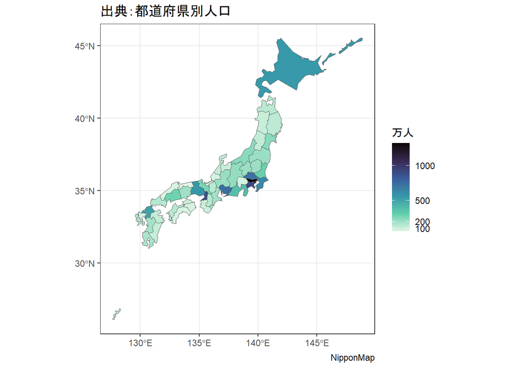

```r
#閾値
my_breaks <- c(100, 200, 500, 1000)

#可視化
ggplot()+
  geom_sf(data=Nippon_map, aes(fill=population/10000))+
  scale_fill_viridis_c(option="G",
                       direction=-1,
                       breaks=my_breaks)+
  labs(fill="万人",
       caption="NipponMap")+
  ggtitle("出典：都道府県別人口")+
  theme_bw()
```

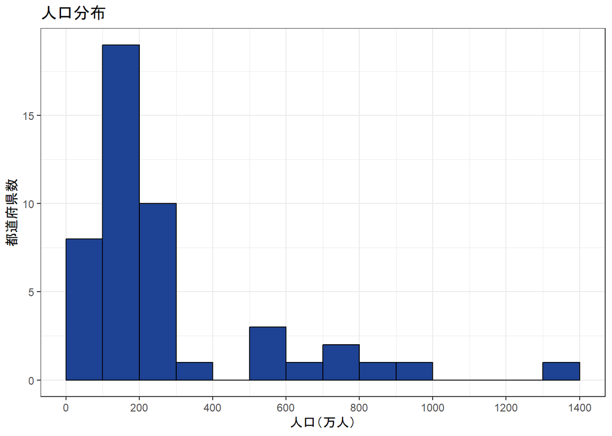

# 3 対数による人口分布の可視化

**目盛の変更**

度数分布の横軸を対数化．[^1]

- 人口を，10を底とする常用対数に変換．
  - 左側の目盛幅が広くなり，人口の少ない都道府県数が詳細になる．
  - 一方，右側の目盛幅は狭くなるが，度数が少ないため，情報は失われない．
  - 分布のバランスが改善する．

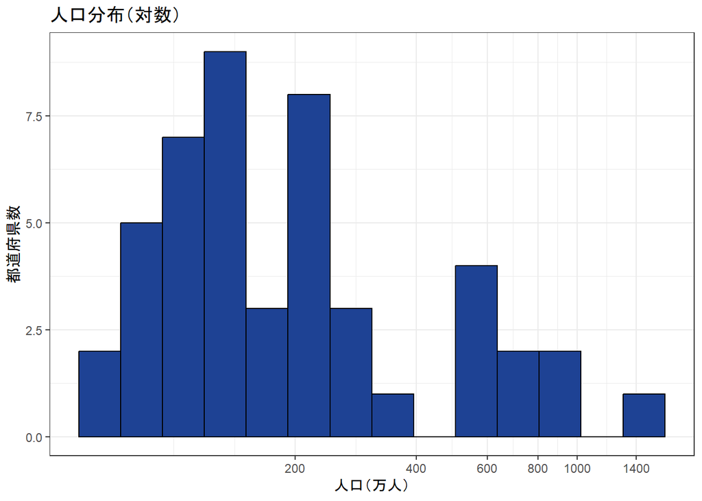

完成図の作成．

- `trans="log10"`により，人口を10を底とする常用対数に変換．
  - 凡例の目盛幅が**変化**．
  - 島根県と鳥取県の色が異なる．
  - `theme_bw()`から`theme_void()`に変更．

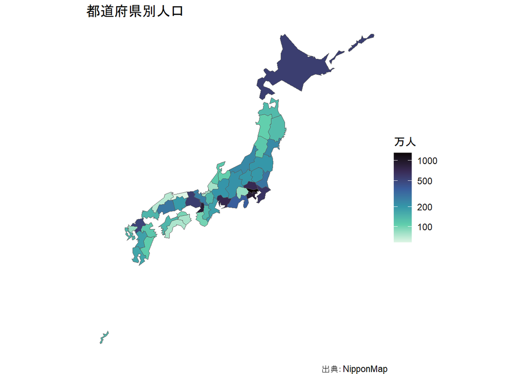

```r
ggplot()+
  geom_sf(data=Nippon_map, aes(fill=population/10000))+
  scale_fill_viridis_c(option="G",
                       direction=-1,
                       trans="log10",
                       breaks=my_breaks)+
  labs(fill="万人",
       caption="出典：NipponMap")+
  ggtitle("都道府県別人口")+
  theme_void()
```

**参考ウェブサイト**

- [Geospatial Data Science With R: Application in Environmental Geography](https://www.bookdown.org/mcwimberly/gdswr-book/) - [9.2 Zone size and raster spatial resolution](https://www.bookdown.org/mcwimberly/gdswr-book/combining-raster-and-vector-data-1---gridded-meteorological-data.html#zone-size-and-raster-spatial-resolution)（アクセス日：2022/06/29）

**RによるGISデータの可視化**

- チュートリアル[ホーム](https://shinichiro-iwata.github.io/geospatial-data-visualization/)
[^1]: 左側に偏り，右裾が長い分布を対数正規分布とよぶ．対数正規分布を対数変換すると正規分布に近づく性質がある．